# Optimal Treatment Analysis

## Outcome Variable

**Outcome Variable:** whz

## Predictor Variables

**Intervention Variable:** predexfd6

**Adjustment Set:**

- arm
- sex
- W_mage
- meducyrs
- feducyrs
- hhwealth_quart
- hfoodsec
- W_mhtcm
- vagbrth
- W_gagebrth
- W_birthwt
- W_birthlen
- W_nrooms
- W_nchldlt5
- month
- brthmon
- W_parity
- impfloor
- impsan
- safeh20
- delta_W_mage
- delta_meducyrs
- delta_feducyrs
- delta_hhwealth_quart
- delta_hfoodsec
- delta_W_mhtcm
- delta_vagbrth
- delta_W_gagebrth
- delta_W_birthwt
- delta_W_birthlen
- delta_W_nrooms
- delta_W_nchldlt5
- delta_month
- delta_brthmon
- delta_W_parity
- delta_impfloor
- delta_impsan
- delta_safeh20

## Stratifying Variables

The analysis was stratified on these variable(s):

- agecat
- studyid
- country

## Data Summary

| agecat | studyid | country | predexfd6 | n_cell | n |
| --- | --- | --- | --- | --- | --- |
| Birth | ki0047075b-MAL-ED | BANGLADESH | 1 | 114 | 219 |
| Birth | ki0047075b-MAL-ED | BANGLADESH | 0 | 105 | 219 |
| Birth | ki0047075b-MAL-ED | BRAZIL | 1 | 26 | 168 |
| Birth | ki0047075b-MAL-ED | BRAZIL | 0 | 142 | 168 |
| Birth | ki0047075b-MAL-ED | INDIA | 1 | 15 | 187 |
| Birth | ki0047075b-MAL-ED | INDIA | 0 | 172 | 187 |
| Birth | ki0047075b-MAL-ED | NEPAL | 1 | 22 | 165 |
| Birth | ki0047075b-MAL-ED | NEPAL | 0 | 143 | 165 |
| Birth | ki0047075b-MAL-ED | PERU | 1 | 104 | 249 |
| Birth | ki0047075b-MAL-ED | PERU | 0 | 145 | 249 |
| Birth | ki0047075b-MAL-ED | SOUTH AFRICA | 1 | 3 | 209 |
| Birth | ki0047075b-MAL-ED | SOUTH AFRICA | 0 | 206 | 209 |
| Birth | ki0047075b-MAL-ED | TANZANIA, UNITED REPUBLIC OF | 1 | 1 | 115 |
| Birth | ki0047075b-MAL-ED | TANZANIA, UNITED REPUBLIC OF | 0 | 114 | 115 |
| Birth | ki1000108-CMC-V-BCS-2002 | INDIA | 1 | 7 | 7 |
| Birth | ki1000108-CMC-V-BCS-2002 | INDIA | 0 | 0 | 7 |
| Birth | ki1000108-IRC | INDIA | 1 | 0 | 12 |
| Birth | ki1000108-IRC | INDIA | 0 | 12 | 12 |
| Birth | ki1000109-EE | PAKISTAN | 1 | 0 | 1 |
| Birth | ki1000109-EE | PAKISTAN | 0 | 1 | 1 |
| Birth | ki1000304b-SAS-CompFeed | INDIA | 1 | 45 | 47 |
| Birth | ki1000304b-SAS-CompFeed | INDIA | 0 | 2 | 47 |
| Birth | ki1101329-Keneba | GAMBIA | 1 | 451 | 1336 |
| Birth | ki1101329-Keneba | GAMBIA | 0 | 885 | 1336 |
| Birth | kiGH5241-JiVitA-3 | BANGLADESH | 1 | 12395 | 15420 |
| Birth | kiGH5241-JiVitA-3 | BANGLADESH | 0 | 3025 | 15420 |
| Birth | kiGH5241-JiVitA-4 | BANGLADESH | 1 | 521 | 633 |
| Birth | kiGH5241-JiVitA-4 | BANGLADESH | 0 | 112 | 633 |
| 6 months | ki0047075b-MAL-ED | BANGLADESH | 1 | 123 | 235 |
| 6 months | ki0047075b-MAL-ED | BANGLADESH | 0 | 112 | 235 |

[output cut: 64 more lines]

The following strata were considered:

- agecat: 24 months, studyid: ki0047075b-MAL-ED, country: BANGLADESH
- agecat: 24 months, studyid: ki0047075b-MAL-ED, country: BRAZIL
- agecat: 24 months, studyid: ki0047075b-MAL-ED, country: INDIA
- agecat: 24 months, studyid: ki0047075b-MAL-ED, country: NEPAL
- agecat: 24 months, studyid: ki0047075b-MAL-ED, country: PERU
- agecat: 24 months, studyid: ki0047075b-MAL-ED, country: SOUTH AFRICA
- agecat: 24 months, studyid: ki0047075b-MAL-ED, country: TANZANIA, UNITED REPUBLIC OF
- agecat: 24 months, studyid: ki1000108-CMC-V-BCS-2002, country: INDIA
- agecat: 24 months, studyid: ki1000108-IRC, country: INDIA
- agecat: 24 months, studyid: ki1017093b-PROVIDE, country: BANGLADESH
- agecat: 24 months, studyid: ki1101329-Keneba, country: GAMBIA
- agecat: 24 months, studyid: ki1113344-GMS-Nepal, country: NEPAL
- agecat: 24 months, studyid: ki1148112-LCNI-5, country: MALAWI
- agecat: 24 months, studyid: kiGH5241-JiVitA-3, country: BANGLADESH
- agecat: 24 months, studyid: kiGH5241-JiVitA-4, country: BANGLADESH
- agecat: 6 months, studyid: ki0047075b-MAL-ED, country: BANGLADESH
- agecat: 6 months, studyid: ki0047075b-MAL-ED, country: BRAZIL
- agecat: 6 months, studyid: ki0047075b-MAL-ED, country: INDIA
- agecat: 6 months, studyid: ki0047075b-MAL-ED, country: NEPAL
- agecat: 6 months, studyid: ki0047075b-MAL-ED, country: PERU
- agecat: 6 months, studyid: ki0047075b-MAL-ED, country: SOUTH AFRICA
- agecat: 6 months, studyid: ki0047075b-MAL-ED, country: TANZANIA, UNITED REPUBLIC OF
- agecat: 6 months, studyid: ki1000108-CMC-V-BCS-2002, country: INDIA
- agecat: 6 months, studyid: ki1000108-IRC, country: INDIA
- agecat: 6 months, studyid: ki1000109-EE, country: PAKISTAN
- agecat: 6 months, studyid: ki1000304b-SAS-CompFeed, country: INDIA
- agecat: 6 months, studyid: ki1000304b-SAS-FoodSuppl, country: INDIA
- agecat: 6 months, studyid: ki1017093b-PROVIDE, country: BANGLADESH
- agecat: 6 months, studyid: ki1101329-Keneba, country: GAMBIA
- agecat: 6 months, studyid: ki1113344-GMS-Nepal, country: NEPAL
- agecat: 6 months, studyid: ki1148112-LCNI-5, country: MALAWI
- agecat: 6 months, studyid: kiGH5241-JiVitA-3, country: BANGLADESH
- agecat: 6 months, studyid: kiGH5241-JiVitA-4, country: BANGLADESH
- agecat: Birth, studyid: ki0047075b-MAL-ED, country: BANGLADESH
- agecat: Birth, studyid: ki0047075b-MAL-ED, country: BRAZIL
- agecat: Birth, studyid: ki0047075b-MAL-ED, country: INDIA
- agecat: Birth, studyid: ki0047075b-MAL-ED, country: NEPAL
- agecat: Birth, studyid: ki0047075b-MAL-ED, country: PERU
- agecat: Birth, studyid: ki0047075b-MAL-ED, country: SOUTH AFRICA
- agecat: Birth, studyid: ki0047075b-MAL-ED, country: TANZANIA, UNITED REPUBLIC OF
- agecat: Birth, studyid: ki1000108-CMC-V-BCS-2002, country: INDIA
- agecat: Birth, studyid: ki1000108-IRC, country: INDIA
- agecat: Birth, studyid: ki1000109-EE, country: PAKISTAN
- agecat: Birth, studyid: ki1000304b-SAS-CompFeed, country: INDIA
- agecat: Birth, studyid: ki1101329-Keneba, country: GAMBIA
- agecat: Birth, studyid: kiGH5241-JiVitA-3, country: BANGLADESH
- agecat: Birth, studyid: kiGH5241-JiVitA-4, country: BANGLADESH

### Dropped Strata

Some strata were dropped due to rare outcomes:

- agecat: Birth, studyid: ki0047075b-MAL-ED, country: SOUTH AFRICA
- agecat: Birth, studyid: ki0047075b-MAL-ED, country: TANZANIA, UNITED REPUBLIC OF
- agecat: Birth, studyid: ki1000108-CMC-V-BCS-2002, country: INDIA
- agecat: Birth, studyid: ki1000108-IRC, country: INDIA
- agecat: Birth, studyid: ki1000109-EE, country: PAKISTAN
- agecat: Birth, studyid: ki1000304b-SAS-CompFeed, country: INDIA
- agecat: 6 months, studyid: ki0047075b-MAL-ED, country: SOUTH AFRICA
- agecat: 6 months, studyid: ki0047075b-MAL-ED, country: TANZANIA, UNITED REPUBLIC OF
- agecat: 6 months, studyid: ki1000108-CMC-V-BCS-2002, country: INDIA
- agecat: 6 months, studyid: ki1000108-IRC, country: INDIA
- agecat: 6 months, studyid: ki1000304b-SAS-FoodSuppl, country: INDIA
- agecat: 24 months, studyid: ki0047075b-MAL-ED, country: SOUTH AFRICA
- agecat: 24 months, studyid: ki0047075b-MAL-ED, country: TANZANIA, UNITED REPUBLIC OF
- agecat: 24 months, studyid: ki1000108-CMC-V-BCS-2002, country: INDIA
- agecat: 24 months, studyid: ki1000108-IRC, country: INDIA

## Methods Detail

We’re interested in the causal parameters $E[Y_a]$ for all values of $a \in \mathcal{A}$. These parameters represent the mean outcome if, possibly contrary to fact, we intervened to set all units to have $A=a$. Under the randomization and positivity assumptions, these are identified by the statistical parameters $\psi_a=E_W[E_{Y|A,W}(Y|A=a,W)]$. In addition, we’re interested in the mean of $Y$, $E[Y]$ under no intervention (the observed mean). We will estimate these parameters by using SuperLearner to fit the relevant likelihood factors – $E_{Y|A,W}(Y|A=a,W)$ and $p(A=a|W)$, and then updating our likelihood fit using a joint TMLE.

For unadjusted analyses ($W=\{\}$), initial likelihoods were estimated using Lrnr_glm to estimate the simple $E(Y|A)$ and Lrnr_mean to estimate $p(A)$. For adjusted analyses, a small library containing Lrnr_glmnet, Lrnr_xgboost, and Lrnr_mean was used.

Having estimated these parameters, we will then use the delta method to estimate relative risks and attributable risks relative to a prespecified baseline level of $A$.

# Results Detail

## Results Plots

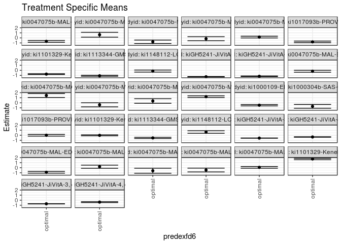

## Results Table

### Parameter: TSM

| agecat | studyid | country | intervention_level | baseline_level | estimate | ci_lower | ci_upper |
| --- | --- | --- | --- | --- | --- | --- | --- |
| Birth | ki0047075b-MAL-ED | BANGLADESH | optimal | observed | -0.9055127 | -1.0796535 | -0.7313719 |
| Birth | ki0047075b-MAL-ED | BRAZIL | optimal | observed | 0.2011931 | -0.1133601 | 0.5157462 |
| Birth | ki0047075b-MAL-ED | INDIA | optimal | observed | -0.5977498 | -1.0989896 | -0.0965100 |
| Birth | ki0047075b-MAL-ED | NEPAL | optimal | observed | -0.4584137 | -0.8380166 | -0.0788107 |
| Birth | ki0047075b-MAL-ED | PERU | optimal | observed | 0.0688709 | -0.0972722 | 0.2350140 |
| Birth | ki1101329-Keneba | GAMBIA | optimal | observed | 1.7346265 | 1.5942789 | 1.8749742 |
| Birth | kiGH5241-JiVitA-3 | BANGLADESH | optimal | observed | -0.7158175 | -0.7370906 | -0.6945443 |
| Birth | kiGH5241-JiVitA-4 | BANGLADESH | optimal | observed | -0.3871227 | -0.4830489 | -0.2911964 |
| 6 months | ki0047075b-MAL-ED | BANGLADESH | optimal | observed | -0.1787499 | -0.3703391 | 0.0128394 |
| 6 months | ki0047075b-MAL-ED | BRAZIL | optimal | observed | 1.4460015 | 1.0493210 | 1.8426821 |
| 6 months | ki0047075b-MAL-ED | INDIA | optimal | observed | -0.4039820 | -0.8111492 | 0.0031853 |
| 6 months | ki0047075b-MAL-ED | NEPAL | optimal | observed | 0.3585476 | -0.0939157 | 0.8110108 |
| 6 months | ki0047075b-MAL-ED | PERU | optimal | observed | 1.2139594 | 1.0435153 | 1.3844036 |
| 6 months | ki1000109-EE | PAKISTAN | optimal | observed | -0.4784993 | -0.6172221 | -0.3397765 |
| 6 months | ki1000304b-SAS-CompFeed | INDIA | optimal | observed | -0.7024985 | -1.0772887 | -0.3277082 |
| 6 months | ki1017093b-PROVIDE | BANGLADESH | optimal | observed | 0.0033159 | -0.1649179 | 0.1715497 |
| 6 months | ki1101329-Keneba | GAMBIA | optimal | observed | -0.0184396 | -0.1156612 | 0.0787821 |
| 6 months | ki1113344-GMS-Nepal | NEPAL | optimal | observed | -0.5286057 | -0.6489629 | -0.4082486 |
| 6 months | ki1148112-LCNI-5 | MALAWI | optimal | observed | 0.6417418 | 0.3946865 | 0.8887970 |
| 6 months | kiGH5241-JiVitA-3 | BANGLADESH | optimal | observed | -0.5638846 | -0.5854905 | -0.5422787 |
| 6 months | kiGH5241-JiVitA-4 | BANGLADESH | optimal | observed | -0.3448320 | -0.3916204 | -0.2980436 |
| 24 months | ki0047075b-MAL-ED | BANGLADESH | optimal | observed | -0.6878709 | -0.8645153 | -0.5112265 |
| 24 months | ki0047075b-MAL-ED | BRAZIL | optimal | observed | 0.6198385 | 0.1396687 | 1.1000084 |
| 24 months | ki0047075b-MAL-ED | INDIA | optimal | observed | -0.7755019 | -1.1224034 | -0.4286003 |
| 24 months | ki0047075b-MAL-ED | NEPAL | optimal | observed | -0.1702119 | -0.5658831 | 0.2254594 |
| 24 months | ki0047075b-MAL-ED | PERU | optimal | observed | 0.1565948 | -0.0119340 | 0.3251236 |
| 24 months | ki1017093b-PROVIDE | BANGLADESH | optimal | observed | -0.7942712 | -0.9516832 | -0.6368592 |
| 24 months | ki1101329-Keneba | GAMBIA | optimal | observed | -0.7465653 | -0.8258788 | -0.6672517 |
| 24 months | ki1113344-GMS-Nepal | NEPAL | optimal | observed | -1.0771877 | -1.1765133 | -0.9778620 |
| 24 months | ki1148112-LCNI-5 | MALAWI | optimal | observed | -0.1376946 | -0.3426883 | 0.0672991 |
| 24 months | kiGH5241-JiVitA-3 | BANGLADESH | optimal | observed | -1.2765724 | -1.3193631 | -1.2337817 |
| 24 months | kiGH5241-JiVitA-4 | BANGLADESH | optimal | observed | -1.1769557 | -1.2354168 | -1.1184946 |

### Parameter: E(Y)

| agecat | studyid | country | intervention_level | baseline_level | estimate | ci_lower | ci_upper |
| --- | --- | --- | --- | --- | --- | --- | --- |
| Birth | ki0047075b-MAL-ED | BANGLADESH | observed | observed | -0.9925114 | -1.1346572 | -0.8503656 |
| Birth | ki0047075b-MAL-ED | BRAZIL | observed | observed | 0.4073214 | 0.2229599 | 0.5916830 |
| Birth | ki0047075b-MAL-ED | INDIA | observed | observed | -1.0435829 | -1.1865715 | -0.9005943 |
| Birth | ki0047075b-MAL-ED | NEPAL | observed | observed | -0.9226061 | -1.0630064 | -0.7822058 |
| Birth | ki0047075b-MAL-ED | PERU | observed | observed | -0.0430924 | -0.1600210 | 0.0738362 |
| Birth | ki1101329-Keneba | GAMBIA | observed | observed | 1.6904416 | 1.6057966 | 1.7750867 |
| Birth | kiGH5241-JiVitA-3 | BANGLADESH | observed | observed | -0.7234060 | -0.7433920 | -0.7034200 |
| Birth | kiGH5241-JiVitA-4 | BANGLADESH | observed | observed | -0.3738863 | -0.4580087 | -0.2897638 |
| 6 months | ki0047075b-MAL-ED | BANGLADESH | observed | observed | -0.1464929 | -0.2779745 | -0.0150113 |
| 6 months | ki0047075b-MAL-ED | BRAZIL | observed | observed | 0.9717225 | 0.8073791 | 1.1360658 |
| 6 months | ki0047075b-MAL-ED | INDIA | observed | observed | -0.7028736 | -0.8283047 | -0.5774424 |
| 6 months | ki0047075b-MAL-ED | NEPAL | observed | observed | 0.1167518 | -0.0146454 | 0.2481490 |
| 6 months | ki0047075b-MAL-ED | PERU | observed | observed | 1.0554461 | 0.9322755 | 1.1786167 |
| 6 months | ki1000109-EE | PAKISTAN | observed | observed | -0.7212766 | -0.8346857 | -0.6078675 |
| 6 months | ki1000304b-SAS-CompFeed | INDIA | observed | observed | -0.6348861 | -0.7630511 | -0.5067211 |
| 6 months | ki1017093b-PROVIDE | BANGLADESH | observed | observed | -0.2083706 | -0.2927992 | -0.1239419 |
| 6 months | ki1101329-Keneba | GAMBIA | observed | observed | -0.1997850 | -0.2531586 | -0.1464114 |
| 6 months | ki1113344-GMS-Nepal | NEPAL | observed | observed | -0.6015049 | -0.6892785 | -0.5137313 |
| 6 months | ki1148112-LCNI-5 | MALAWI | observed | observed | 0.3927574 | 0.2737700 | 0.5117448 |
| 6 months | kiGH5241-JiVitA-3 | BANGLADESH | observed | observed | -0.5931801 | -0.6126929 | -0.5736674 |
| 6 months | kiGH5241-JiVitA-4 | BANGLADESH | observed | observed | -0.3971948 | -0.4378192 | -0.3565704 |
| 24 months | ki0047075b-MAL-ED | BANGLADESH | observed | observed | -0.8315789 | -0.9546058 | -0.7085521 |
| 24 months | ki0047075b-MAL-ED | BRAZIL | observed | observed | 0.4466272 | 0.2416144 | 0.6516401 |
| 24 months | ki0047075b-MAL-ED | INDIA | observed | observed | -0.9390848 | -1.0545919 | -0.8235777 |
| 24 months | ki0047075b-MAL-ED | NEPAL | observed | observed | -0.3703084 | -0.4835704 | -0.2570464 |
| 24 months | ki0047075b-MAL-ED | PERU | observed | observed | 0.1430051 | 0.0254144 | 0.2605957 |
| 24 months | ki1017093b-PROVIDE | BANGLADESH | observed | observed | -0.8879412 | -0.9708680 | -0.8050144 |
| 24 months | ki1101329-Keneba | GAMBIA | observed | observed | -0.8032329 | -0.8532842 | -0.7531817 |
| 24 months | ki1113344-GMS-Nepal | NEPAL | observed | observed | -1.1369520 | -1.2269975 | -1.0469065 |
| 24 months | ki1148112-LCNI-5 | MALAWI | observed | observed | -0.0771196 | -0.2204715 | 0.0662323 |
| 24 months | kiGH5241-JiVitA-3 | BANGLADESH | observed | observed | -1.2991319 | -1.3225545 | -1.2757094 |
| 24 months | kiGH5241-JiVitA-4 | BANGLADESH | observed | observed | -1.2337581 | -1.2679680 | -1.1995482 |

### Parameter: PAR

| agecat | studyid | country | intervention_level | baseline_level | estimate | ci_lower | ci_upper |
| --- | --- | --- | --- | --- | --- | --- | --- |
| Birth | ki0047075b-MAL-ED | BANGLADESH | optimal | observed | -0.0869987 | -0.2251832 | 0.0511858 |
| Birth | ki0047075b-MAL-ED | BRAZIL | optimal | observed | 0.2061284 | -0.0561901 | 0.4684468 |
| Birth | ki0047075b-MAL-ED | INDIA | optimal | observed | -0.4458331 | -0.9294385 | 0.0377723 |
| Birth | ki0047075b-MAL-ED | NEPAL | optimal | observed | -0.4641924 | -0.8194094 | -0.1089753 |
| Birth | ki0047075b-MAL-ED | PERU | optimal | observed | -0.1119633 | -0.2409326 | 0.0170061 |
| Birth | ki1101329-Keneba | GAMBIA | optimal | observed | -0.0441849 | -0.1544067 | 0.0660369 |
| Birth | kiGH5241-JiVitA-3 | BANGLADESH | optimal | observed | -0.0075885 | -0.0156682 | 0.0004912 |
| Birth | kiGH5241-JiVitA-4 | BANGLADESH | optimal | observed | 0.0132364 | -0.0373046 | 0.0637774 |
| 6 months | ki0047075b-MAL-ED | BANGLADESH | optimal | observed | 0.0322570 | -0.1003208 | 0.1648348 |
| 6 months | ki0047075b-MAL-ED | BRAZIL | optimal | observed | -0.4742790 | -0.8390265 | -0.1095316 |
| 6 months | ki0047075b-MAL-ED | INDIA | optimal | observed | -0.2988916 | -0.6954500 | 0.0976668 |
| 6 months | ki0047075b-MAL-ED | NEPAL | optimal | observed | -0.2417958 | -0.6575406 | 0.1739489 |
| 6 months | ki0047075b-MAL-ED | PERU | optimal | observed | -0.1585133 | -0.2937974 | -0.0232292 |
| 6 months | ki1000109-EE | PAKISTAN | optimal | observed | -0.2427773 | -0.3413059 | -0.1442486 |
| 6 months | ki1000304b-SAS-CompFeed | INDIA | optimal | observed | 0.0676124 | -0.3469319 | 0.4821567 |
| 6 months | ki1017093b-PROVIDE | BANGLADESH | optimal | observed | -0.2116865 | -0.3612047 | -0.0621682 |
| 6 months | ki1101329-Keneba | GAMBIA | optimal | observed | -0.1813454 | -0.2612786 | -0.1014122 |
| 6 months | ki1113344-GMS-Nepal | NEPAL | optimal | observed | -0.0728992 | -0.1498852 | 0.0040869 |
| 6 months | ki1148112-LCNI-5 | MALAWI | optimal | observed | -0.2489844 | -0.4619393 | -0.0360295 |
| 6 months | kiGH5241-JiVitA-3 | BANGLADESH | optimal | observed | -0.0292955 | -0.0390575 | -0.0195336 |
| 6 months | kiGH5241-JiVitA-4 | BANGLADESH | optimal | observed | -0.0523628 | -0.0731419 | -0.0315837 |
| 24 months | ki0047075b-MAL-ED | BANGLADESH | optimal | observed | -0.1437081 | -0.2795330 | -0.0078831 |
| 24 months | ki0047075b-MAL-ED | BRAZIL | optimal | observed | -0.1732113 | -0.5920238 | 0.2456012 |
| 24 months | ki0047075b-MAL-ED | INDIA | optimal | observed | -0.1635830 | -0.4967740 | 0.1696080 |
| 24 months | ki0047075b-MAL-ED | NEPAL | optimal | observed | -0.2000965 | -0.5655573 | 0.1653643 |
| 24 months | ki0047075b-MAL-ED | PERU | optimal | observed | -0.0135897 | -0.1367465 | 0.1095671 |
| 24 months | ki1017093b-PROVIDE | BANGLADESH | optimal | observed | -0.0936700 | -0.2315075 | 0.0441675 |
| 24 months | ki1101329-Keneba | GAMBIA | optimal | observed | -0.0566677 | -0.1214399 | 0.0081046 |
| 24 months | ki1113344-GMS-Nepal | NEPAL | optimal | observed | -0.0597643 | -0.1206839 | 0.0011553 |
| 24 months | ki1148112-LCNI-5 | MALAWI | optimal | observed | 0.0605750 | -0.0669630 | 0.1881131 |
| 24 months | kiGH5241-JiVitA-3 | BANGLADESH | optimal | observed | -0.0225595 | -0.0592129 | 0.0140939 |
| 24 months | kiGH5241-JiVitA-4 | BANGLADESH | optimal | observed | -0.0568024 | -0.1012421 | -0.0123627 |